# Practical Machine Learning Project

Patrick Newsom

Sunday, March 22, 2015

### Introduction:

With the advent of fitness devices, data collection and studies in Human Activity Recognition has become inexpensive. While people regularly quantify how much of a particular activity they do, they rarely quantify how well they do it. This project’s goal will be to use data provided from various sensors on the belt, forearm, arm, and dumbbell of 6 participants to determine proper exercise execution as well as mistake detection. The experiment is more formally described below:

```
Participants were asked to perform one set of 10 repetitions of the Unilateral Dumbbell Biceps Curl in five
different fashions: exactly according to the specification (Class A), throwing the elbows to the front
(Class B), lifting the dumbbell only halfway (Class C), lowering the dumbbell only halfway (Class D) and
throwing the hips to the front (Class E). Class A corresponds to the specified execution of the exercise, while
the other 4 classes correspond to common mistakes. [1]
```

### Project Scope:

1. Gain understanding of the machine learning process.
2. Utilizing data provided, build a machine learning algorithm to predict activity quality from various activity monitors placed on the body and exercise equipment.

### Obtaining Data Files and Partitioning:

The initial scripting loads the required libraries into R, sets the working directory, and downloads the necessary data files if they’re not stored locally.

```r
library(caret); library(rgl); library(rattle); library(rpart); library(randomForest)
library(foreach); library(parallel); library(doParallel)

# set working directory ----
if (getwd() != "C:/Users/patrick/Documents/R_Workspace/Pratical Machine Learning/Poject"){
   setwd("C:/Users/patrick/Documents/R_Workspace/Practical Machine Learning/Project")
}

# get datafiles ----
file_1 = "pml-training.csv"; file_2 = "pml-testing.csv"
train_source <- "https://d396qusza40orc.cloudfront.net/predmachlearn/pml-training.csv"
test_source <-"https://d396qusza40orc.cloudfront.net/predmachlearn/pml-testing.csv"

if (!file.exists(file_1)){
   download.file(train_source, destfile = file_1)
}
if (!file.exists(file_2)){
   download.file(test_source, destfile = file_2)
}
```

The dataset is large having 19,622 observations of 160 variables. The dataset is split 70/30 into partitions for training and testing.

```r
# create dataframe ----
train.df <- read.csv(file_1, na.strings = c("", "NA", "#DIV/0!"))
dim(train.df)
```

```
[1] 19622   160
```

```r
# create data partitionins ----
set.seed(121)
partition = createDataPartition(train.df$classe, p = 0.70, list= FALSE)
training = train.df[partition,]; testing = train.df[-partition,]
```

### Data Cleaning and Exploration

The dataset provided for analysis is dirty due to the approaches used in the original experiment to create features the experimenters felts was necessary.

```
For feature extraction we used a sliding window approach with different lengths from 0.5 second to 2.5 seconds,
with 0.5 second overlap. In each step of the sliding window approach we calculated features on the Euler angles
(roll, pitch and yaw), as well as the raw accelerometer, gyroscope and magnetometer readings. For the Euler
angles of each of the four sensors, we calculated eight features: mean, variance, standard deviation, max, min,
amplitude, kurtosis and skewness, generating in total 96 derived feature sets. [1]
```

Examining the data it can be seen that many of the columns conatined NA values. These are removed. The first 7 columns are also removed since they provide no useful data for determining which exercised is performed.

```r
# Data cleaning ----
training <- training[, complete.cases(t(training))] # eliminate incomplete columns
plot.df <- training[training$user_name == "carlitos",] # data exploration only
training <- training[, -seq(1:7)] # remove remaining unwanted columns
names(training)
```

```
 [1] "roll_belt"            "pitch_belt"           "yaw_belt"
 [4] "total_accel_belt"     "gyros_belt_x"         "gyros_belt_y"
 [7] "gyros_belt_z"         "accel_belt_x"         "accel_belt_y"
[10] "accel_belt_z"         "magnet_belt_x"        "magnet_belt_y"
[13] "magnet_belt_z"        "roll_arm"             "pitch_arm"
[16] "yaw_arm"              "total_accel_arm"      "gyros_arm_x"
[19] "gyros_arm_y"          "gyros_arm_z"          "accel_arm_x"
[22] "accel_arm_y"          "accel_arm_z"          "magnet_arm_x"
[25] "magnet_arm_y"         "magnet_arm_z"         "roll_dumbbell"
[28] "pitch_dumbbell"       "yaw_dumbbell"         "total_accel_dumbbell"
[31] "gyros_dumbbell_x"     "gyros_dumbbell_y"     "gyros_dumbbell_z"
[34] "accel_dumbbell_x"     "accel_dumbbell_y"     "accel_dumbbell_z"
[37] "magnet_dumbbell_x"    "magnet_dumbbell_y"    "magnet_dumbbell_z"
[40] "roll_forearm"         "pitch_forearm"        "yaw_forearm"
[43] "total_accel_forearm"  "gyros_forearm_x"      "gyros_forearm_y"
[46] "gyros_forearm_z"      "accel_forearm_x"      "accel_forearm_y"
[49] "accel_forearm_z"      "magnet_forearm_x"     "magnet_forearm_y"
[52] "magnet_forearm_z"     "classe"
```

As it can be seen, the training dataset is reduced to 53 variables from the original 160. A subset of the training file was taken to examine various features from the sensors(accelorometer, gyroscope, and magnetometer) and their calculated Euler angles to determine on which parameter the exercises performed could be separable. Two examples are shown below in 3 dimensional plots. These plots are interactive allowing for plot rotation and resizing using the mouse butons and mouse wheel. The color scheme to identify each exercise activity is: **A black**, **B red**, **C green**, **D blue**, and **E cyan**

[interactive chart not shown]

[interactive chart not shown]

### Preprocessing:

The training data was examined to determine the correlation between variables. Strongly correlated variables (magintude > 0.8) were removed. 13 variables were removed from the training data. The reduced variable dataset will be referred to as training.cor.

```r
# PreProcessing - reduce variables used in modeling ----
M <- cor(training[, -dim(training)[2]])
M <- upper.tri(as.matrix(M))*M
W <- which(abs(M)>0.8, arr.ind = TRUE)
names(training[,unique(W[,2])])
```

```
 [1] "yaw_belt"         "total_accel_belt" "accel_belt_x"
 [4] "accel_belt_y"     "accel_belt_z"     "magnet_belt_x"
 [7] "gyros_arm_y"      "magnet_arm_x"     "magnet_arm_z"
[10] "gyros_dumbbell_z" "accel_dumbbell_x" "accel_dumbbell_z"
[13] "gyros_forearm_z"
```

```r
training.cor <- training[, -unique(W[,2])]
```

A principal component analysis was performed to see if there can be a further reduction of the variables in the training data. The analysis was performed on the orginal tidy training data and the newly cleaned data to compare the results.

```r
# Is there potential benefit from principal component analysis
training.pca1 <- training[, seq(1:(dim(training)[2]- 1))]
training.pca2 <- training.cor[, seq(1:(dim(training.cor)[2]- 1))]
preObj1 <- preProcess(training.pca1, method = 'pca'); preObj1$numComp
```

```
[1] 25
```

```r
preObj2 <- preProcess(training.pca2, method = 'pca'); preObj2$numComp
```

```
[1] 24
```

Though the results show that we could benefit from preprocessing the data using principal component analysis, a variable important to the machine learning algorithm could be lost based on which training data set is used.

### Data Modeling:

The `classe` variable which determines how the exercise was performed is modeled using a decision tree and random forest. Since the inital results of the decision tree were the same when using the tidy training data and the reduced variable training data, the reduced training data (training.cor) was used in all subsequent models.

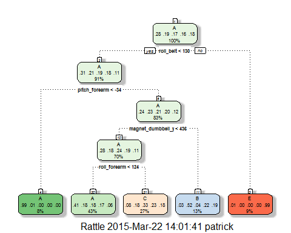

```r
# Model Training ----
set.seed(125)
# decision tree
# treeModel <- train(classe ~., method='rpart', data= training)
treeModel <- train(classe ~., method='rpart', data= training.cor)
fancyRpartPlot(treeModel$finalModel)
```

```r
treePredict <- predict(treeModel, newdata = training)
confusionMatrix(treePredict, training$classe)
```

```
Confusion Matrix and Statistics

          Reference
Prediction    A    B    C    D    E
         A 3549 1070 1098 1004  360
         B   61  942   79  399  344
         C  284  646 1219  849  657
         D    0    0    0    0    0
         E   12    0    0    0 1164

Overall Statistics

               Accuracy : 0.5004
                 95% CI : (0.492, 0.5088)
    No Information Rate : 0.2843
    P-Value [Acc > NIR] : < 2.2e-16

                  Kappa : 0.3474
 Mcnemar's Test P-Value : NA

Statistics by Class:

                     Class: A Class: B Class: C Class: D Class: E
Sensitivity            0.9086  0.35440  0.50876   0.0000  0.46099
Specificity            0.6407  0.92030  0.78520   1.0000  0.99893
Pos Pred Value         0.5012  0.51616  0.33352      NaN  0.98980
Neg Pred Value         0.9464  0.85594  0.88326   0.8361  0.89165
Prevalence             0.2843  0.19349  0.17442   0.1639  0.18381
Detection Rate         0.2584  0.06857  0.08874   0.0000  0.08473
Detection Prevalence   0.5155  0.13285  0.26607   0.0000  0.08561
Balanced Accuracy      0.7747  0.63735  0.64698   0.5000  0.72996
```

As can be seen, the results decision tree modeling are not very good. The model proved to be 50% accurate. Because output from using the `confusionMatrix()` command is so verbose, the confusion matrix and acccuracy of other models will be determined without the function.

Random forest modeling was performed using boot632 subsampling (with 99 iterations) and kfold (with 5 folds) cross validations. Two boot632 models were performed because it was determined that the combination of principal components analysis preprocessing and removing variables from the training data might have impacted modeling results as suggested earlier. To improve processing time, parallel processing was used on 3 of 4 available threads on a Dell Inspiron model 15R laptop (2.53 Ghz, i3 duo core processor with hyperthreading) in a Microsoft Windows 7 environment.

```r
# random forest
cl <- makeCluster(3)
registerDoParallel(cl)

 tr_control <- trainControl(method= 'boot632', number= 99)
 rfModel.boot632 <- train(classe ~., method= 'rf', preProcess= 'pca',
                  trControl= tr_control, data= training.cor, tuneLength = 1)

 rfModel.boot632_2 <- train(classe ~., method= 'rf', trControl= tr_control,
                          data= training.cor, tuneLength = 1)

tr_control <- trainControl(method= 'cv', number= 5)
rfModel.kfold <- train(classe ~., method= 'rf', trControl= tr_control,
                  data= training.cor, tuneLength = 1)

stopCluster(cl)
```

### Evaluating Results:

After training each of the models, predictions were made on the testind data partition which had not been manipulated in any way after it was created. It can be shown that there are still 160 columns in the set.

```r
dim(testing)
```

```
[1] 5885  160
```

```r
pred.boot632 <- predict(rfModel.boot632, newdata= testing)
pred.boot632_2 <- predict(rfModel.boot632_2, newdata= testing)
pred.kfold <- predict(rfModel.kfold, newdata= testing)
```

The out of sample error is determined by first calulating each models accuracy and later subtrating it from 1.

```r
accuracy.boot632 <- round(sum(pred.boot632 == testing$classe)/length(testing$classe), 3)
accuracy.boot632_2 <- round(sum(pred.boot632_2 == testing$classe)/length(testing$classe), 3)
accuracy.kfold <- round(sum(pred.kfold == testing$classe)/length(testing$classe), 3)
```

The random forest model with boot632 cross validation and using principal components analysis had and accuracy of 97.1 percent and an out of sample error rate of 2.9 percent. The confusion matrix for the model is below.

```r
table(pred.boot632, testing$classe)
```

```
pred.boot632    A    B    C    D    E
           A 1658   22    3    6    1
           B    2 1095   25    2   10
           C   10   18  991   38    7
           D    3    0    7  914    9
           E    1    4    0    4 1055
```

The random forest model with boot632 cross validation and not using principal components analysis had an accuracy of 99.4 percent and an out of sample error rate of 0.6 percent. The confusion matrix for the model is below.

```r
table(pred.boot632_2, testing$classe)
```

```
pred.boot632_2    A    B    C    D    E
             A 1673    8    0    0    0
             B    1 1125    9    0    0
             C    0    6 1015    8    1
             D    0    0    2  955    1
             E    0    0    0    1 1080
```

```r
table(pred.kfold, testing$classe)
```

```
pred.kfold    A    B    C    D    E
         A 1673    9    0    0    0
         B    1 1126    7    0    0
         C    0    4 1017   10    1
         D    0    0    2  953    1
         E    0    0    0    1 1080
```

### Project Submission:

The final test for determining modeling accuracy was to submit prediction results to see how well they scored. Students were given two attempts. The results from each random forest model are below.

```r
# submission set
submission.df <- read.csv(file_2, na.strings = c("", "NA", "#DIV/0!"))
predict(rfModel.boot632, newdata = submission.df)
```

```
 [1] B A A A A E D B A A A C B A E E A B B B
Levels: A B C D E
```

Admittedly, the results of this model were submitted without first determining model accuracy. I missed entries 3 and 11, scoring 18 of 20 correctly.

```r
predict(rfModel.boot632_2, newdata = submission.df)
```

```
 [1] B A B A A E D B A A B C B A E E A B B B
Levels: A B C D E
```

```r
predict(rfModel.kfold, newdata = submission.df)
```

```
 [1] B A B A A E D B A A B C B A E E A B B B
Levels: A B C D E
```

The prediction results of the final 2 models were identical. When submitted, I scored 20 out of 20 correctly. Interestingly, re-examining the confusion matrices of the various models shows that the first model would be more likely to have errors in determining exercise type B from A.

### Conclusion:

It has been shown that properly applied, a machine learning algorithm can be used to discern human activity and proper exercise form. The original researchers concluded however that this was not yet feasible due to a wide variety of factors that could occur in an uncontrolled environment.

It was shown that utilizing 2 preprocessing methods negatively impacted results in one of the machine models. A fourth model could be run using principal components analysis without removing any variables from the training set to determine if there would be improvements to prediction. Additionally, the principal components analysis thresh-hold (whose default value = 0.95) could have been increased to accommodate for more variables. [1]

### References:

1. Velloso, E.; Bulling, A.; Gellersen, H.; Ugulino, W.; Fuks, H. *Qualitative Activity Recognition of Weight Lifting Exercises.* Proceedings of 4th International Conference in Cooperation with SIGCHI (Augmented Human ’13). Stuttgart, Germany: ACM SIGCHI, 2013
2. Leek, J., Peng, R.,Caffo, B., *Practical Machine Learning*, John Hopkins University Bloomberg School of Public Health, March 2015.